# Figures_Sendra2023

## Load required libraries

For single cell data processing, plotting and managing dataframes

```r
suppressMessages({

  # Data Manipulation and Analysis
  library(openxlsx)        # For reading and writing Excel files
  library(tidyverse)       # For data manipulation
  library(magrittr)        # Provides the pipe operator (%>%)
  library("dgof")          # Statistics KS test compare distributions

  # Single-cell Analysis
  library(MouseGastrulationData)  # Custom package for specific mouse gastrulation data
  library(SingleCellExperiment)   # Represents a single-cell experiment
  library(Seurat)                 # Tools for single-cell genomics
  library(Signac)                 # Analyzing single-cell chromatin data
  library(UCell)                  # Analysis and visualization of single-cell genomics data

  # Genomic Data Handling
  library(rtracklayer)   # Handling and manipulating genomic data tracks
  library(GenomicRanges)  # Representing, transforming, and querying genomic intervals

  # Data Visualization
  library(ggplot2)        # Comprehensive plotting package
  library(gridExtra)      # Combining multiple ggplots into a single plot

  # Genomic Annotation
  library(ChIPpeakAnno)   # Annotating ChIP-seq peak data
  library(ggseqlogo)      # Plot motif sequences
})
```

## Define directories

They will be relative to wherever this .Rmd file is located at the moment.

```r
# Define relative paths
data <- "./data"        # Where data is loaded from
figures <- "./figures"  # Where figures are saved
results <- "./results"  # Where results. For example: a dataframe of marker peaks, a .rds dataframe calculated previous to plotting...
```

Following the order of Results section

# scRNAseq: Re-analysis of previously published data

## Figures S1_1-4: scRNAseq signature scores

### Download data from MouseGastrulation package

If it is already downloaded, load it from local.

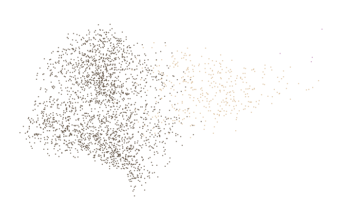

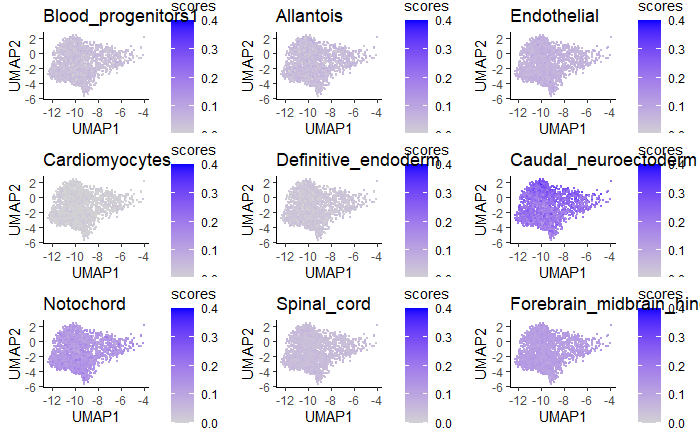

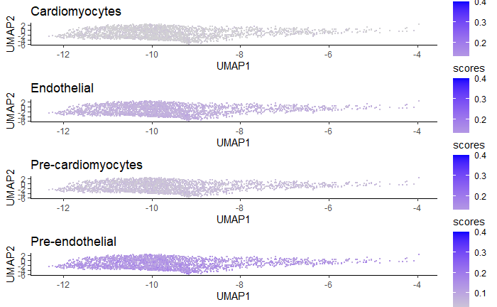

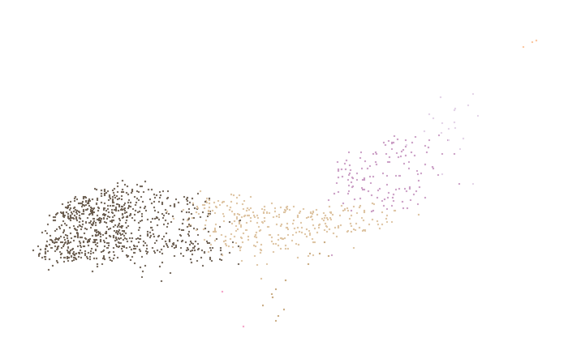

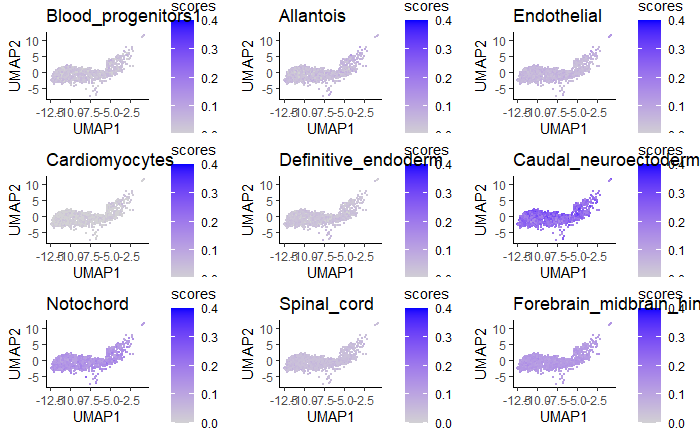

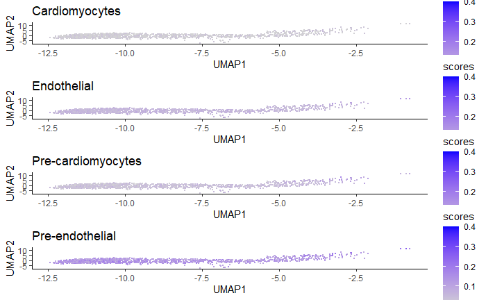

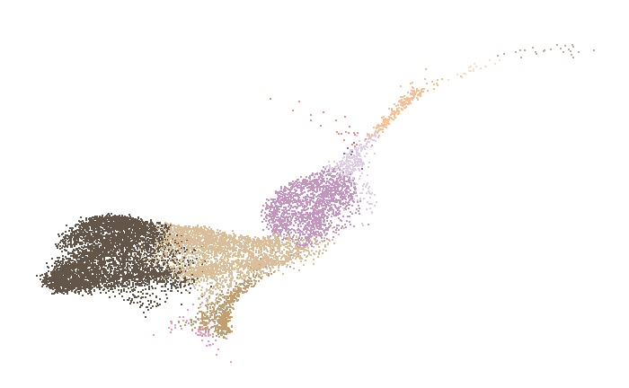

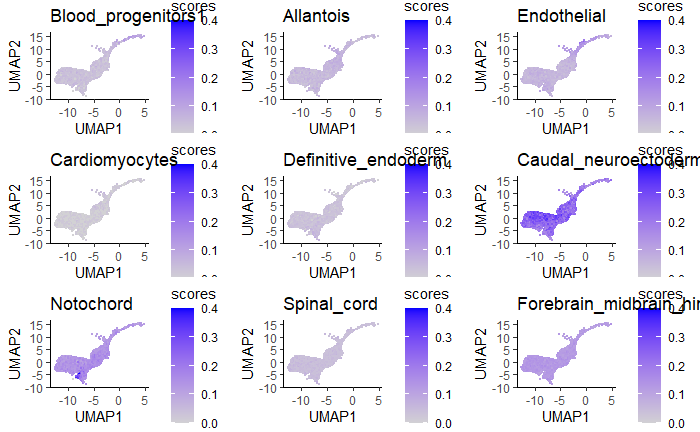

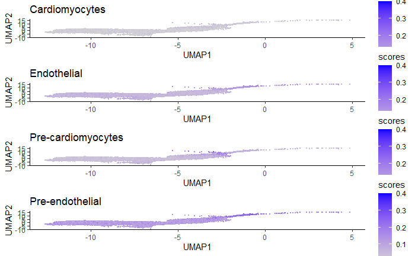

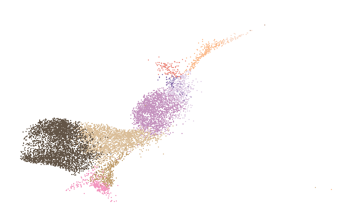

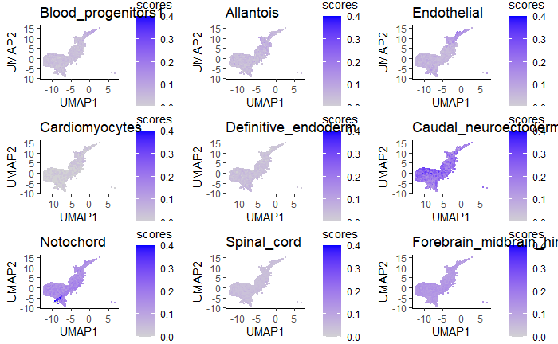

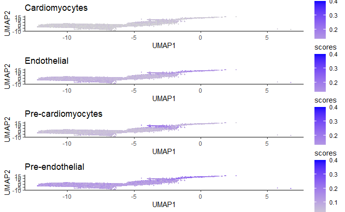

```r
# Define the target stages
target_stages <- c("E6.5", "E6.75", "E7.0", "E7.25")

# Loop over each target stage
for (target_stage in target_stages) {

  # Download data from MouseGastrulation package
  sce_path <- file.path(data, "scRNAseq_PijuanSala2019_MouseGastrulationAtlas", paste0(target_stage, "_sce_subset.rds"))

  if (!file.exists(sce_path)) {
    print(paste0(target_stage, " sce dataset does not exist. Downloading from MouseGastrulationData package"))
    # If the file doesn't exist, proceed with downloading, subsetting, and saving it

    # Import only samples from the specified stages
    target_samples <- AtlasSampleMetadata %>%
      filter(stage %in% target_stage) %>%
      pull(sample)

    # Download the data (SingleCellExperiment format, sce)
    sce <- EmbryoAtlasData(samples = target_samples)

    # Define the celltypes you want to keep
    desired_celltypes <- c('Epiblast', 'Primitive Streak', 'Nascent mesoderm', 'Mixed mesoderm', "ExE mesoderm",
                           "Anterior Primitive Streak", "Mixed mesoderm", "Haematoendothelial progenitors",
                           "Mesenchyme", "Endothelium", "Cardiomyocytes", "Def. endoderm", "Blood progenitors 1",
                           "Blood progenitors 2")

    # Subset the sce object based on the desired celltypes
    sce <- sce[, sce$celltype %in% desired_celltypes]

    sce %>%
      saveRDS(sce_path)

  } else {
    # If the file exists, just load it
    sce <- readRDS(sce_path) # load local file
  }

  # Calculate U Scores using Ucell Package
  scores_path <- file.path(results, paste0(target_stage, "u_scores.rds"))
  scores_heart_path <- file.path(results, paste0(target_stage, "u_scores_heart.rds"))

  if (!file.exists(scores_path)) { # compute only if you have not computed it before. It takes some time

    # import signatures (list of celltype genes)
    # if signatures ensembl files are not there. you will need to transform gene marker lists to ensembl using this code:
    # data/scRNAseq_PijuanSala2019_MouseGastrulationAtlas/extract_ensembl_signatures.Rmd"
    signatures <- readRDS(file.path(data, "scRNAseq_PijuanSala2019_MouseGastrulationAtlas", "signatures_celltype_ensembl.rds"))
    signatures_heart <- readRDS(file.path(data, "scRNAseq_PijuanSala2019_MouseGastrulationAtlas", "signatures_heart_celltype_ensembl.rds"))

    # Extract matrix with counts and Ensembl ids from the sce object, necessary to compute UCell scores
    counts <- assay(sce, "counts")

    # E6.75 stages needs for some unkown reason this conversion step. Its counts are stored in dgMatrix format and it can't be read by Ucell
    if (target_stage == "E6.75"){
    counts <- as.matrix(counts)
    }

    # Run ScoreSignatures_UCell and get directly signature scores for all cells
    u.scores <- ScoreSignatures_UCell(counts, features = signatures)

    u.scores %>%
      saveRDS(file.path(results, paste0(target_stage, "u_scores.rds")))

    # Run ScoreSignatures_UCell again for heart markers
    u.scores_heart <- ScoreSignatures_UCell(counts, features = signatures_heart)

    u.scores_heart %>%
      saveRDS(file.path(results, paste0(target_stage, "u_scores_heart.rds")))

  } else {
    u.scores <- readRDS(scores_path)
    u.scores_heart <- readRDS(scores_heart_path)
  }

  ### Before plotting UCell scores, plot the celltype map for reference

  # Define the color palette as a named vector (copied from Pijuan-Sala2019 code)
  # https://github.com/MarioniLab/MouseGastrulationData

  # Define the color palette as a named vector (copied from Pijuan-Sala2019 code)
  celltype_colors <- c(
    "Epiblast" = "#635547",
    "Primitive Streak" = "#DABE99",
    "Nascent mesoderm" = "#C594BF",
    "Mixed mesoderm" = "#DFCDE4",
    "ExE mesoderm" = "#8870ad",
    "Anterior Primitive Streak" = "#c19f70",
    "Haematoendothelial progenitors" = "#FBBE92",
    "Mesenchyme" = "#ed8f84",
    "Endothelium" = "#eda450",
    "Cardiomyocytes" = "#B51D8D",
    "Def. endoderm" = "#F397C0",
    "Blood progenitors 1" = "#f9decf",
    "Blood progenitors 2" = "#c9a997"
  )

  # Extract UMAP coordinates to plot the score of each signature
  umap_coordinates <- reducedDim(sce, "umap")

  # Create a data frame for plotting
  plot_data <- data.frame(
    UMAP1 = umap_coordinates[, 1],
    UMAP2 = umap_coordinates[, 2],
    celltype = colData(sce)$celltype  # Add cell types from colData
  )

  # Create the UMAP plot with the combined data and color mapping
  p <- ggplot(plot_data, aes(x = UMAP1, y = UMAP2, color = celltype)) +
    geom_point(size = 0.2) +
    scale_color_manual(values = celltype_colors) +  # Use the custom color palette
    labs(title = "") + # no title
    theme_minimal() +
    theme(
      panel.grid.major = element_blank(),
      panel.grid.minor = element_blank(),
      axis.title.x = element_blank(),
      axis.title.y = element_blank(),
      axis.text.x = element_blank(),
      axis.text.y = element_blank(),
      axis.ticks = element_blank()
    )+
    guides(color = FALSE)  # Remove the color legend, this will be added with adobe illustrator manually

  # Print the UMAP plot
  print(p)

  ggsave(file.path(figures,  paste0(paste(target_stage, collapse = " "), "_Celltypes.png")), plot = p, width = 3, height = 3)


  ### Plot U Scores for each of the analyzed cell types using ggplot

  # Plot all celltype scores in all timepoint. Relative scale color to each plot. Even small differences will show up, although they are small compared differences comparing with other cell types.
  # Function to create a UMAP plot for a specific cell type
  create_umap_plot <- function(sce, umap_coordinates, u.scores, celltype, ylim_max) {
    # Create a data frame for plotting
    plot_data <- data.frame(
      UMAP1 = umap_coordinates[, 1],
      UMAP2 = umap_coordinates[, 2],
      scores = u.scores[, paste0(celltype, "_UCell")]
    )

    # Create the UMAP plot with signature score levels
    p <- ggplot(plot_data, aes(x = UMAP1, y = UMAP2, color = scores
    )) +
      geom_point(size = 0.2) +
      scale_colour_gradient2(
      low = "#d2d1d4",
      mid = "#9f7aeb",
      high = "#0802ff",
      midpoint = ylim_max/2,
      na.value = "#d2d1d4",
      limits = c(0, ylim_max) # in case you want to set a common scale for all celltypes
      ) +
      labs(title = paste(celltype)) +
      theme(panel.grid.major = element_blank(), panel.grid.minor = element_blank(),
            panel.background = element_blank(), axis.line = element_line(colour = "black"), # legend.position = "none"  # Remove the legend
      )
    return(p)
  }

  # Now plot all cell type signatures together in a grid
  # ylim_max <- max(u.scores) # in case you want to set a common scale for all celltypes
  ylim_max <- 0.4

  # cell types to loop over
  celltypes <- names(signatures)

  # order names in order of gastrulation, ingression to Primitive streak (Tam et al 1997)
  celltypes <- c("Blood_progenitors1", "Allantois", "Endothelial", "Cardiomyocytes", "Definitive_endoderm", "Caudal_neuroectoderm", "Notochord", "Spinal_cord", "Forebrain_midbrain_hindbrain")

  # Create a list of plots for each cell type using lapply
  umap_plots <- lapply(celltypes, create_umap_plot, sce = sce, umap_coordinates = umap_coordinates, u.scores = u.scores, ylim_max = ylim_max)

  # Number of columns and rows for the grid
  num_columns <- 3

  # Create a grid of plots
  grid_plot <- do.call("grid.arrange", c(umap_plots, ncol = num_columns))

  # Save the grid of plots to a PNG file with DPI = 600
  score_type <- deparse(substitute(u.scores))
  ggsave(file.path(figures, paste0(score_type, target_stage, ".png")), plot = grid_plot, width = 9, height = 7, dpi = 600)

  # Do the same but only for cardiac scores
  # ylim_max <- max(u.scores) # in case you want to set a common scale for all celltypes

  # cell types to loop over
  celltypes_heart <- names(signatures_heart)

  # Create a list of plots for each cell type using lapply
  umap_plots <- lapply(celltypes_heart, create_umap_plot, sce = sce, umap_coordinates = umap_coordinates, u.scores = u.scores_heart, ylim_max = ylim_max)

  # Number of columns and rows for the grid
  num_columns <- 1

  # Create a grid of plots
  grid_plot <- do.call("grid.arrange", c(umap_plots, ncol = num_columns))

  # Save the grid of plots to a PNG file with DPI = 600
  score_type <- deparse(substitute(u.scores_heart))
  ggsave(file.path(figures, paste0(score_type, target_stage, ".png")), plot = grid_plot, width = 3.5, height = 10, dpi = 600)

}
```

# snATACseq: Our data

## Figure 1: Epigenetic priming of embryonic lineages in the mouse epiblast

Single nucleus chromatin accessibility profiling reveals cell type priming in the E6.5 epiblast. Endoderm-like and endothelial-like signatures appear in Epiblast snATACseq clusters

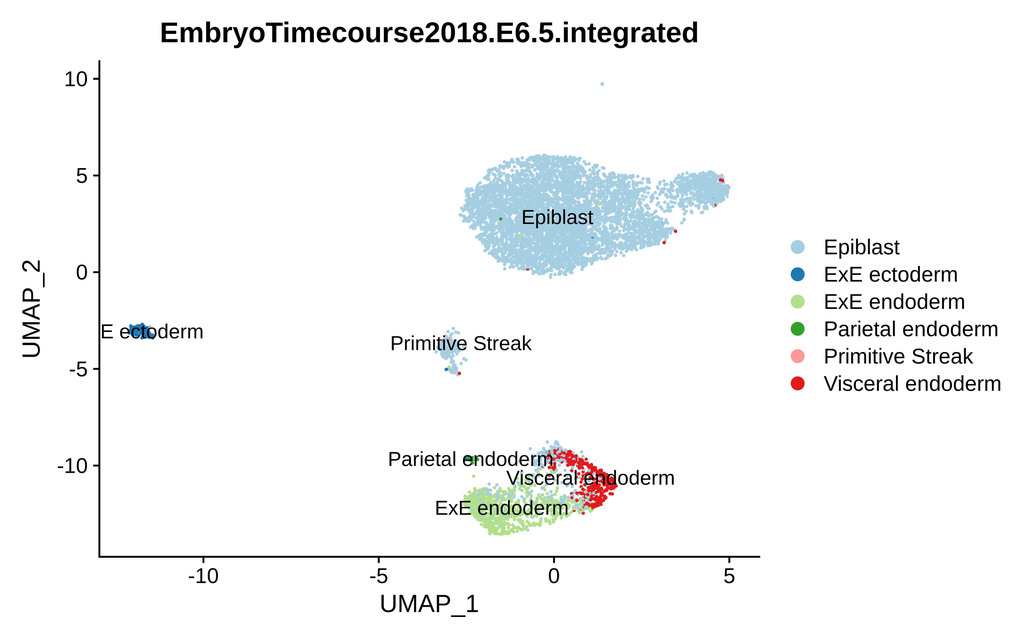

### C Epiblast clustering

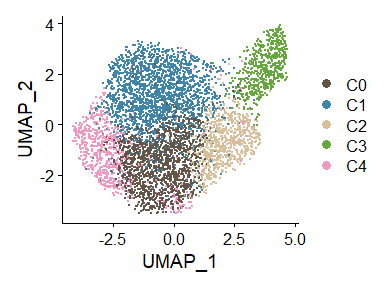

### D Marker peaks

#### Calculate peaks differentially accessible between clusters

Compute marker peaks with seurat function FindAllmarkers

```r
minPct <- 25  # % of cells that need to have that peak accessible to be considered a marker.
pval <- 0.01

cluster.markers <- snATAC %>%
  FindAllMarkers(
    assay = "peaks"
    , slot = "data"
    , min.pct = minPct/100
    , return.thresh = pval
    , test.use = "LR"
    , verbose = T
    , latent.vars = "nCount_peaks"
  )

# Select cluster markers with padj_val < 0.01, discard the rest
cluster.markers.padjval <- cluster.markers %>%
  subset(p_val_adj < 0.01)
```

#### Annotate peaks with gene names which TSS lay in the same regulatory region.

We will use the reference (Shen et al., 2012). This reference considers that every piece of DNA within the same hi-C TAD is able to interact with each other. It takes into account that the same peak (i.e. enhancer) can interact with multiple genes’ TSS.

```r
# RDS file that already has the bed annotated with the region and its genes. It is a GRanges object.
reg <- readRDS(file.path(data, "snATACseq", "regulatory_regions_annot.rds"))

peaks <- cluster.markers.padjval

# This code creates a new column "region" with the values from the "gene" column and then removes the original "gene" column. T
peaks$region <- peaks$gene
peaks <- peaks[, -which(names(peaks) == "gene")]

peak.regions <- peaks$region

### Peak annotation
# Perform peak annotation by finding overlapping regions in the regulatory region annotation
peak.reg_ids <- sapply(peak.regions, function (x) {subsetByOverlaps(reg, StringToGRanges(x))$reg_id})
# Add the regulatory region IDs to the peaks data
peaks$regulatory_reg <- peak.reg_ids
```

[output not shown]

#### Annotate peaks with gene names with closest TSS even if they do not share regulatory region

Some peaks were not annotated in previous round. create a second annotation column in the cluster.markers dataframe to gather info about the closest gene to the peak. Although the first annotation we did with the regulatory region is more accurate than finding just the closest gene.

```r
### Annotate with nearest genes
# Some peaks do not belong to any of the annotated regulatory regions in the reference. We create a new column that annotates the closest TSS, regardless of the regulatory regions.
peaks_closestTSS <- peaks %>%
  left_join(ClosestFeature(snATAC, regions = peaks$region),
            by = join_by(region == query_region)) %>%
  dplyr::rename(pct_cluster = pct.1, pct_rest = pct.2, closest_TSS = gene_name, TSS_in_same_regulatory_region = gene_TSS) %>%    # rename columns
  dplyr::select(-gene_id, -tx_id) %>% # remove useless columns
  distinct()                          # remove duplicates
### Add info about position (is the region inside a gene, is it anterior?)
peaks_closestTSS <- peaks_closestTSS %>%
  filter(!is.na(closest_region)) %>%
  mutate(anterior = StringToGRanges(region) < StringToGRanges(closest_region)) %>%
  mutate(in_gene_region = distance == 0 | (distance < 2000 & anterior == T))

# Order result by fold.enrichment within each cluster
peaks_closestTSS <- peaks_closestTSS %>%
  arrange(cluster, desc(avg_log2FC))

# save
peaks_closestTSS %>%
  write.table(file.path(results, "Epiblast_clusters_marker_peaks_annotated_reg.tsv"),
            row.names = F, col.names = T, quote = F, sep = "\t")

peaks_closestTSS %>% head()
```

|  | cluster | region | p_val | avg_log2FC | pct_cluster | pct_rest | p_val_adj | regulatory_reg | TSS_in_same_regulatory_region | closest_TSS | gene_biotype | type | closest_region | distance | anterior | in_gene_region |
| --- | --- | --- | --- | --- | --- | --- | --- | --- | --- | --- | --- | --- | --- | --- | --- | --- |
| 1 | C0 | chr11-3192878-3193770 | 2.561530e-14 | 0.2858224 | 0.669 | 0.808 | 7.061140e-09 | reg_1075 | Sfi1,Gm11399,Gm12735,Eif4enif1 | Sfi1 | protein_coding | utr | chr11-3193360-3193424 | 0 | TRUE | TRUE |
| 2 | C0 | chr17-39847616-39848386 | 6.698609e-11 | -0.3361323 | 0.679 | 0.885 | 1.846545e-05 | NA | NA | CT010467.1 | rRNA | gap | chr17-39848133-39848134 | 0 | TRUE | TRUE |
| 3 | C0 | chr17-39842970-39843829 | 2.542306e-11 | -0.3626095 | 0.674 | 0.886 | 7.008147e-06 | NA | NA | CT010467.1 | rRNA | exon | chr17-39846353-39848201 | 2523 | TRUE | FALSE |
| 4 | C1 | chr4-136081166-136082072 | 1.735306e-24 | 1.0535237 | 0.251 | 0.125 | 4.783561e-19 | reg_5874 | Cnr2,Fuca1,Hmgcl,Gale,Lypla2,Pithd1,Gm13008,Gm24362,Eloa,Rpl11,Id3,E2f2 | Rpl11 | protein_coding | exon | chr4-136053348-136053428 | 27737 | FALSE | FALSE |
| 5 | C1 | chr4-135855551-135856457 | 5.848658e-21 | 0.9733185 | 0.250 | 0.138 | 1.612247e-15 | reg_5873 | Srsf10,Pnrc2 | Srsf10 | protein_coding | cds | chr4-135856227-135856291 | 0 | TRUE | TRUE |
| 6 | C1 | chr15-80083064-80083913 | 1.904527e-20 | 0.9530681 | 0.250 | 0.137 | 5.250037e-15 | reg_2908 | Rpl3,Syngr1,Tab1 | Rpl3 | protein_coding | cds | chr15-80083324-80083326 | 0 | TRUE | TRUE |

#### Plots: Number of marker peaks per cluster

You can start directly from here skipping the FindMarkers and annotation. Just load the .tsv file with the markers

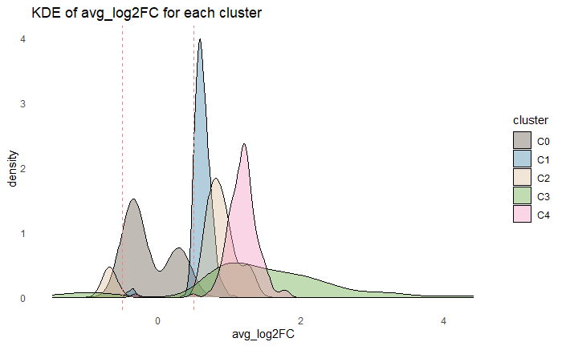

```r
marker_peaks_path <- file.path(results, "Epiblast_clusters_marker_peaks_annotated_reg.tsv")
marker_peaks <- read.delim(marker_peaks_path, sep="\t")

df <- marker_peaks

# KDE plot for the distribution of avg_log2FC on each cluster with a horizontal red line at 0.5
ggplot(df, aes(x = avg_log2FC, fill = cluster)) +
  geom_density(alpha = 0.4) +
  geom_vline(xintercept = 0.5, color = "lightcoral", linetype = "dashed") +
  geom_vline(xintercept = -0.5, color = "lightcoral", linetype = "dashed") +
  scale_fill_manual(values = color.epiblast.named) +
  theme_minimal() +
  theme(panel.grid.major = element_blank(), panel.grid.minor = element_blank()) +
  ggtitle("KDE of avg_log2FC for each cluster")
```

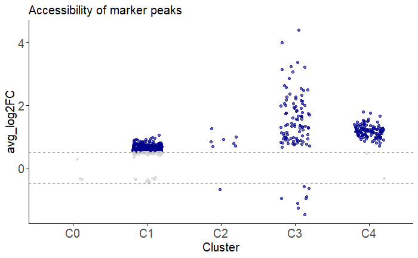

```r
# 2D scatter plot with jitter for avg_log2FC on each cluster

ggplot(df, aes(x = cluster, y = avg_log2FC)) +
  geom_jitter(aes(color = ifelse(abs(avg_log2FC) < 0.5, "lightgray", "darkblue")), width = 0.2, height = 0, size = 1.5, alpha = 0.6) +
  geom_hline(yintercept = 0.5, color = "lightcoral", linetype = "dashed") +
  geom_hline(yintercept = -0.5, color = "lightcoral", linetype = "dashed") +
  scale_color_identity() +
  labs(x = "Cluster", y = "avg_log2FC") +
  theme_minimal() +
  theme(plot.title = element_text(size = 15),
        axis.title = element_text(size = 15),
        axis.text = element_text(size = 15),
        axis.line = element_line(color = "black"),
        axis.ticks = element_line(color = "black"),
        panel.grid.major = element_blank(),
        panel.grid.minor = element_blank()) +
  ggtitle("Accessibility of marker peaks")

# save the plot
ggsave(file.path(figures, paste0("snATAC_E6.5_epiblast_clusters_marker_peaks_scatter", ".png")), width = 6, height = 4, dpi = 600)
```

```r
# save marker peaks table keeping only peaks which abs(log2FC) > 0.5
marker_peaks_log2FC0.5 <- marker_peaks %>%
  subset(abs(avg_log2FC) > 0.5)

marker_peaks_log2FC0.5  %>%
  write.table(file.path(file.path(results, "Epiblast_clusters_marker_peaks_annotated_reg_log2FC0.5.tsv")),
            row.names = F, col.names = T, quote = F, sep = "\t")
```

### E Plot top marker peaks from clusters

(most differentially accesible peak, respectively)

```r
top_marker_peaks <- marker_peaks %>%
  subset(avg_log2FC > 0.5) %>%
  group_by(cluster) %>%
  top_n(1, wt = avg_log2FC) %>% # sort by increasing adjusted p_value
  ungroup()

top_marker_peaks
```

| cluster | region | p_val | avg_log2FC | pct_cluster | pct_rest | p_val_adj | regulatory_reg | TSS_in_same_regulatory_region | closest_TSS | gene_biotype | type | closest_region | distance | anterior | in_gene_region |
| --- | --- | --- | --- | --- | --- | --- | --- | --- | --- | --- | --- | --- | --- | --- | --- |
| C1 | chr4-136081166-136082072 | 1.735306e-24 | 1.053524 | 0.251 | 0.125 | 4.783561e-19 | reg_5874 | Cnr2,Fuca1,Hmgcl,Gale,Lypla2,Pithd1,Gm13008,Gm24362,Eloa,Rpl11,Id3,E2f2 | Rpl11 | protein_coding | exon | chr4-136053348-136053428 | 27737 | FALSE | FALSE |
| C2 | chr3-145684632-145685520 | 2.812153e-24 | 1.260911 | 0.259 | 0.122 | 7.752008e-19 | reg_5418 | Znhit6,Ccn1,Gm17501,Ddah1 | Ccn1 | protein_coding | exon | chr3-145649730-145649981 | 34650 | FALSE | FALSE |
| C3 | chr18-80624873-80625770 | 1.296719e-105 | 4.413894 | 0.269 | 0.014 | 3.574549e-100 | reg_3977 | Gm41790,Nfatc1,Gm50211 | Nfatc1 | protein_coding | gap | chr18-80608026-80635690 | 0 | FALSE | TRUE |
| C4 | chr10-49417007-49417928 | 4.909283e-25 | 1.790547 | 0.286 | 0.064 | 1.353298e-19 | reg_755 | Gm47568,Gm35552,Gm47354,Grik2,Gm26543,Gm47018 | Grik2 | protein_coding | gap | chr10-49404451-49419667 | 0 | FALSE | TRUE |

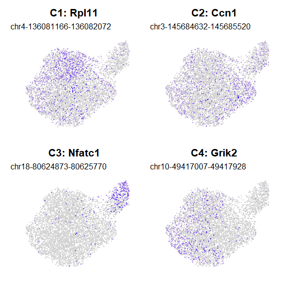

```r
p <- FeaturePlot(snATAC, features = top_marker_peaks$region, order = TRUE) & NoLegend() & NoAxes()
# snATACseq is sparse data, if we do not order, the few cells with accessibility get burried in crowded plots

# Change titles for gene names. Instead of regions, name of cluster and name of the gene
for (i in 1: length(top_marker_peaks$closest_TSS)) p[[i]]$labels$title = paste0(top_marker_peaks$cluster[i], ": ", top_marker_peaks$closest_TSS[i])

# Now add regions as subtitles
for (i in 1: length(top_marker_peaks$region)) p[[i]]$labels$subtitle = top_marker_peaks$region[i]

p
```

```r
# save the plot
ggsave(file.path(figures, paste0("snATAC_E6.5_epiblast_clusters_top_marker_peaks_UMAP", ".png")), width = 6, height = 6, dpi = 600)
```

## Figure 1S6: snATACseq promoter coverage, predicted gene expression + cell-type specific peaks

### Plot foxa2 peak C2

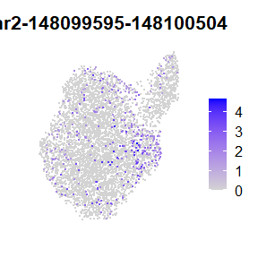

```r
FeaturePlot(snATAC, features = "chr2-148099595-148100504", order = TRUE) & NoAxes()
```

```r
ggsave(file.path(figures, paste0("snATAC_E6.5_epiblast_Foxa2C2_marker_peaks_UMAP", ".png")), width = 4, height = 3, dpi = 600)
```

### Plot Sox9 peak C4

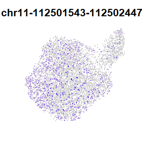

```r
FeaturePlot(snATAC, features = "chr11-112501543-112502447", order = TRUE) & NoAxes() & NoLegend()
```

```r
ggsave(file.path(figures, paste0("snATAC_E6.5_epiblast_Sox9C4_nolegend_marker_peaks_UMAP", ".png")), width = 3, height = 3, dpi = 600)
```

### Plot Notch1 peak C3

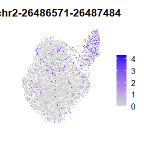

```r
FeaturePlot(snATAC, features = "chr2-26486571-26487484", order = TRUE) & NoAxes()
```

```r
ggsave(file.path(figures, paste0("snATAC_E6.5_epiblast_Notch1_C3_marker_peaks_UMAP", ".png")), width = 3.5, height = 3, dpi = 600)
```

### RNA predicted expression of gastrulation genes

https://stuartlab.org/signac/articles/pbmc_vignette - Create a gene activity matrix

We plot this to know if our C3 has undergone onset of Mesp1 expression or not. We can try to quantify the activity of each gene in the genome by assessing the chromatin accessibility associated with the gene, and create a new gene activity assay derived from the scATAC-seq data. Here we will use a simple approach of summing the fragments intersecting the gene body and promoter region. To create a gene activity matrix, we extract gene coordinates and extend them to include the 2 kb upstream region (as promoter accessibility is often correlated with gene expression). We then count the number of fragments for each cell that map to each of these regions, using the using the FeatureMatrix() function. These steps are automatically performed by the GeneActivity() function: Calculated previously. data/snATACseq_preprocessing_report

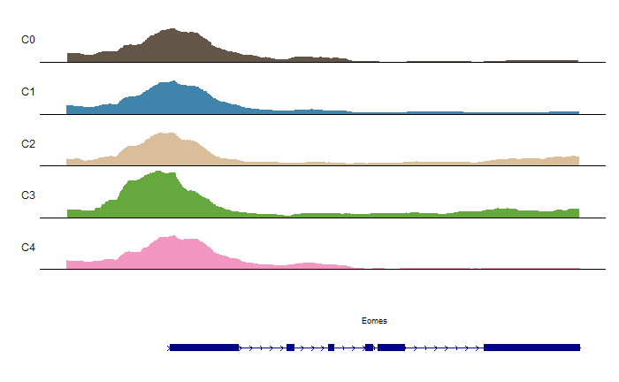

```r
cov_plot & scale_fill_manual(values = color.epiblast.named) & NoLegend() & NoAxes()
```

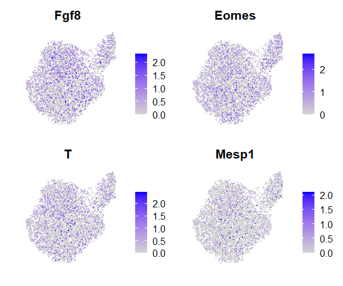

```r
DefaultAssay(snATAC) <- 'RNA'

gastrulation_genes <- c("Fgf8", "Eomes", "T", "Mesp1")

FeaturePlot(snATAC, features = gastrulation_genes, reduction = "umap", order = TRUE) & NoAxes()
```

```r
#ggsave(file.path(figures, paste0("snATAC_E6.5_epiblast_Foxa2C2_marker_peaks_UMAP", ".png")), width = 3, height = 3, dpi = 600)
```

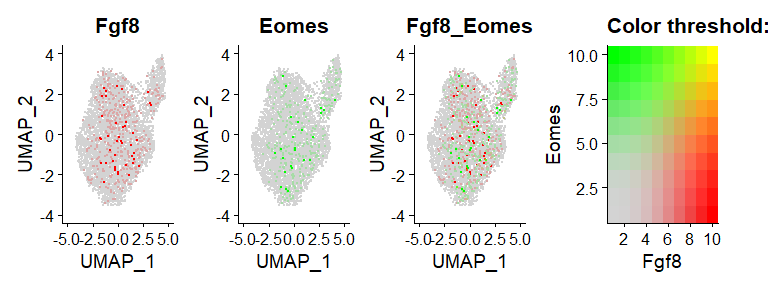

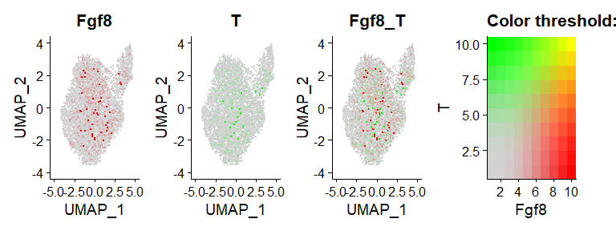

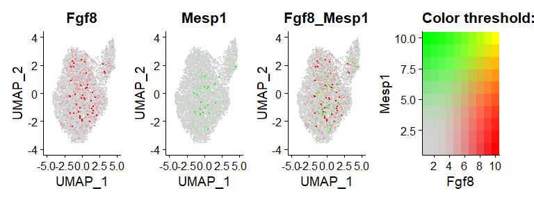

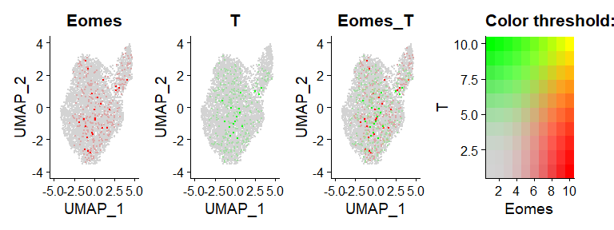

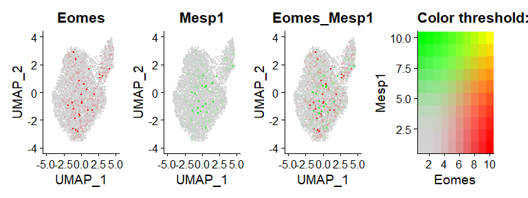

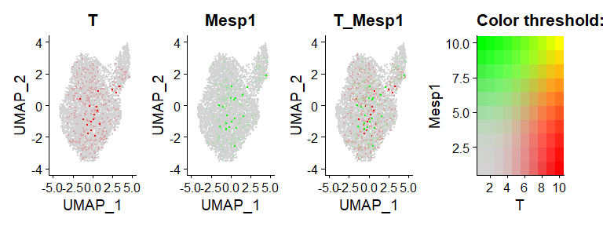

```r
# Visualize co-expression of two features simultaneously
# Get all combinations of 2 items
gene_combinations <- combn(gastrulation_genes, 2, simplify = TRUE)

# Iterate through combinations and create FeaturePlot
for (i in seq(ncol(gene_combinations))) {
  combination <- gene_combinations[, i]
  p <- FeaturePlot(snATAC, features = combination, reduction = "umap", blend = TRUE, order = TRUE)
  print(p)
}
```

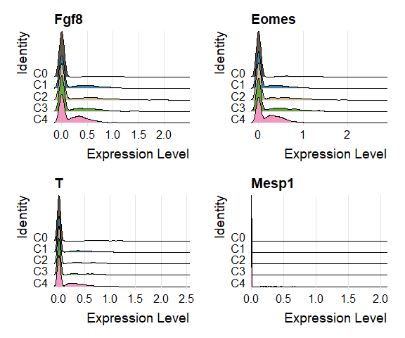

```r
# Define an order of cluster identities
order_clusters <- c("C4", "C3", "C2", "C1", "C0")

# Relevel identities so they appear in order in the plots
snATAC@active.ident <- factor(x = snATAC@active.ident, levels = order_clusters)

RidgePlot(snATAC,
          cols = color.epiblast.named,
          features = gastrulation_genes,
          ncol = 2)
```

```r
ggsave(file.path(figures, paste0("predicted_expression_gastrulation_genes.svg")), width = 6, height = 5, dpi = 600)
```

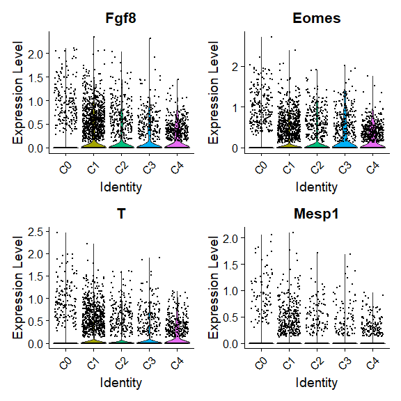

```r
# Put the order back again to normal
# Define an order of cluster identities
order_clusters <- c("C0", "C1", "C2", "C3", "C4")

# Relevel identities so they appear in order in the plots
snATAC@active.ident <- factor(x = snATAC@active.ident, levels = order_clusters)

VlnPlot(snATAC, features = gastrulation_genes, ncol = 2)
```

[figure not shown]

### F Coverage plot of the whole Nfatc1 regulatory region

Plotting from BigWig files obtained from other publications need to be done in a MacOS or Ubuntu. Using Rtracklayer package loading data from bigwigs in Windows is not supported.

```r
# only the first time
fragments_path <- file.path(data, "snATACseq", "fragments.rds")

# Check if the file already exists
if (!file.exists(fragments_path)) {
  # If the file doesn't exist, proceed with creating and saving fragments
  fragments <- CreateFragmentObject(path = file.path(data, "snATACseq", "fragments.tsv.gz"), validate.fragments = TRUE)
  saveRDS(fragments, file_path) # save for next time
} else {
  # If the file exists, just load it
  fragments <- readRDS(file.path(data, "snATACseq" , "fragments.rds")) # load fragments data
}

Fragments(snATAC) <- fragments
```

[output not shown]

Plot coverage of our snATACseq data. E6.5 Epiblast clusters

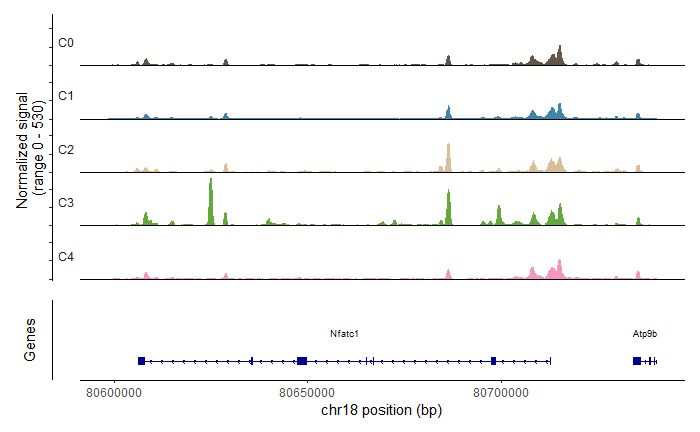

```r
## Determine what regions you are going to plot for the figures
Nfatc1_regulatory_region <- StringToGRanges("chr18:80598312-80740511", sep = c(":", "-"))
  # whole nfatc1 regulatory region extracted from EPUS (Shen et al., 2012)

# Region to plot in the following code:
region <- Nfatc1_regulatory_region

cov_plot <- CoveragePlot(
  object = snATAC,
  region = region,
  links = FALSE,
  annotation = TRUE,   # show genes
  peaks = FALSE,       # do not anotate peaks
  window = 1000        # smoothing
  )

# the color.epiblast vector contains only 5 items

cov_plot & scale_fill_manual(values = color.epiblast.named)
#ggsave(file.path(path, "cov_plot_epiblast_Sendra_region1.svg"), width = 5, height = 5)
ggsave(file.path(figures, paste0("snATAC_E6.5_epiblast_clusters_coverage_plot", ".png")), width = 5, height = 3, dpi = 600)
```

(This chunk will not work on windows OS.)

Lin snATACeq clusters time: 12hours_after_d2-5 condition: dox cell type: embryonic pluripotent stem cells Treatment protocol Doxycycline was added to induce the expression of Mesp1 or Zic3 Growth protocol Pluripotent stem cells were differentiated using published hanging drop protocols (1000 initial cells in serum-condtining medium)

```r
if(.Platform$OS.type != "windows"){

    color.arguelaguet <- c(
  "gray", # Epiblast
  "lightgray",  # PS
  "#13bcc2",  # endothelium
  "#f3756d"  # myocardium
)

# Argelaguet 2022 snATACeq clusters
cov_plot <- BigwigTrack(
  region = region,
  bigwig = BigWigs_Argelaguet,
  smooth = 1000,
  )

cov_plot + scale_fill_manual(values = color.arguelaguet) + theme(legend.position="none") +
  theme(axis.text.x=element_blank(),
        axis.ticks.x=element_blank(),
        axis.text.y=element_blank(),
        axis.ticks.y=element_blank()
        )

ggsave(file.path(figures, paste0("snATAC_E7.5-E8.5_Argelaguet2022_clusters_coverage_plot_bw", ".png")), width = 5, height = 2.5, dpi = 600)

# Lin snATACeq clusters from d2-5 + 12h ESC differentiation to Embryoid bodies

cov_plot <- BigwigTrack(
  region = region,
  bigwig = BigWigs_Argelaguet,
  smooth = 1000,
  )

cov_plot + scale_fill_manual(values = rep("darkblue", 4)) + theme(legend.position="none") +
  theme(axis.text.x=element_blank(),
        axis.ticks.x=element_blank(),
        axis.text.y=element_blank(),
        axis.ticks.y=element_blank()
        )

}else{
  print("bigWig track is not suported on Windows")
}
```

## Figure S1_5: : Supplementary to snATACseq E6.5

### A H3K27 acetilation around snATACseq E6.5 marker peaks in ESCells before and after Mesp1 expression.

I downloaded the BigWig files of the Mesp1 and H3K2chipseqs https://www.ncbi.nlm.nih.gov/geo/query/acc.cgi?acc=GSE165107 GSM5026170 Mesp1-ChIP-seq-12h-dox GSM5026172 H3K27Ac-ChIP-seq-12h-no-dox GSM5026173 H3K27Ac-ChIP-seq-12h-dox

and followed this tutorial: https://bioconductor.org/packages/release/bioc/vignettes/ChIPpeakAnno/inst/doc/ChIPpeakAnno.html Section: Create heatmap for given feature/peak ranges

```r
# Load marker peaks table
marker_peaks_path <- file.path(results, "Epiblast_clusters_marker_peaks_annotated_reg_log2FC0.5.tsv")
marker_peaks_log2FC0.5 <- read.delim(marker_peaks_path, sep="\t")

feature.recentered_path <- file.path(results, "chip_anno_feature.recentered_peaks.RDS")
sig_n_path <- file.path(results, "chip_Mesp1_sig_n.RDS")

if (!file.exists(feature.recentered_path) & !file.exists(sig_n_path)) { # if they do not exist, compute them
  # convert peak region strings to GRanges object
  features <- marker_peaks_log2FC0.5$region %>%
    StringToGRanges(sep = c("-", "-"))

  # add cluster info to metadata
  features$cluster <- marker_peaks_log2FC0.5$cluster

  # Recenter coordinates with +- 2000bp upstream and downstream
  wid <- width(features)
  feature.recentered <- feature.center <- features
  start(feature.center) <- start(features) + floor(wid/2)
  width(feature.center) <- 1
  start(feature.recentered) <- start(feature.center) - 2000
  end(feature.recentered) <- end(feature.center) + 2000

  feature.recentered %>%
    saveRDS(file.path(results, "chip_anno_feature.recentered_peaks.RDS"))

  chip_bigwig_path <- file.path(data, "other_publications", "Lin2022_ChipSeq_ESC_Mesp1_dox")
  chip_files <- list.files(chip_bigwig_path)

  # import signal around feature.recentered (our peaks) ranges
  cvglists <- sapply(file.path(chip_bigwig_path, chip_files), import,
                         format="BigWig",
                         which=feature.recentered,
                         as="RleList")

  # save chip track around our peaks
  cvglists %>%
    saveRDS(file.path(results, "chip_Mesp1_cvglists.RDS"))

  # process signal so it can be plotted in stripplot with ChIPpeakAnno.
  # Basically what it does is 100 bins, such as an histogram
  sig <- cvglists %>%
    ChIPpeakAnno::featureAlignedSignal(
      feature.recentered,
      upstream = 2000,
      downstream = 2000
    )

  # Log2 normalize signal
  sig_n <- sig %>% lapply(\(x) log2(x + 1))

  # Save
  sig_n %>%
    saveRDS(file.path(results, "chip_Mesp1_sig_n.RDS"))

} else { # if exists, load it
  feature.recentered <- readRDS(file.path(results, "chip_anno_feature.recentered_peaks.RDS"))
  sig_n <- readRDS(file.path(results, "chip_Mesp1_sig_n.RDS"))
  }
```